# **Visualización de datos**

Paulina Rosales Becerra

2021-04-18

## General

Los puntos de la tarea vienen indicados con numeración.

### Librería

La única librería utilizada fue `ggplot2`, útil para la graficación de datos.

```r
library(ggplot2)
```

### Datos

El set de datos está compuesto por carácterísticas de pacientes, enfocado a condiciones cardiovasculares.

#### Obtención

Leemos el archivo que vamos a visualizar

1. Abre el archivo “cardiovascular_disease.csv” encontrado en cursos en R (todos los descriptores del dataset se encuentran en el archivo llamado “attributes.txt”).

```r
setwd("/home/paulina/Documents/DataScience/Notebooks/")
dataset <- read.csv("source/cardiovascular_disease.csv")
```

#### Características

Las categorías del set de datos son las siguientes:

```r
names(dataset)
```

```
##  [1] "id"          "age_days"    "age_year"    "gender"      "height"
##  [6] "weight"      "ap_hi"       "ap_lo"       "cholesterol" "gluc"
## [11] "smoke"       "alco"        "active"      "cardio"
```

#### Formateo

Se muestran las primeras líneas del set de datos para darnos una idea la estructura de los datos. Nótese que el tipo de dato de variables categóricas o binarias es `integer`, dichas variables son modificadas a `character` para poder manejarlas como categóricas.

```r
dataset$cardio <- as.character(dataset$cardio)
dataset$gender <- as.character(dataset$gender)
dataset$smoke <- as.character(dataset$smoke)
head(dataset)
```

```
##   id age_days age_year gender height weight ap_hi ap_lo cholesterol gluc smoke
## 1  0    18393 50.39178      2    168     62   110    80           1    1     0
## 2  1    20228 55.41918      1    156     85   140    90           3    1     0
## 3  2    18857 51.66301      1    165     64   130    70           3    1     0
## 4  3    17623 48.28219      2    169     82   150   100           1    1     0
## 5  4    17474 47.87397      1    156     56   100    60           1    1     0
## 6  8    21914 60.03836      1    151     67   120    80           2    2     0
##   alco active cardio
## 1    0      1      0
## 2    0      1      1
## 3    0      0      1
## 4    0      1      1
## 5    0      0      0
## 6    0      0      0
```

## Visualización

De acuerdo a la categoría y objetivo se aplica un tipo de gráfica barras, *pie*, disperción, *boxplot*, etc.) que facilite la comprensión de los datos y sus tendencias.

### Gráfica de barras

2. Realiza una gráfica de barras con el número de pacientes que se encuentran en cada grupo discreto de la variable colesterol.

Para esto primero realizamos el conteo de casos por la categoría de colesterol (*cholesterol* en los datos).

```r
# Extraer los datos relevantes (niveles de colesterol)
counts <- table(dataset$cholesterol)
counts <- as.data.frame(counts)
counts
```

```
##   Var1  Freq
## 1    1 52385
## 2    2  9549
## 3    3  8066
```

Además convertiremos los datos a un formato *long* que nos permitirá graficar con la función `ggplot`.

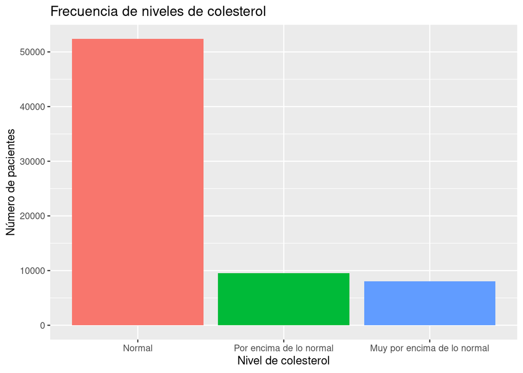

```r
# Graficar las frecuencias de pacientes con niveles de colesterol
ggplot(counts, aes(x = Var1, y = Freq, fill = Var1)) +
  geom_bar(stat = "identity") +
  theme(legend.position = "none") +
  labs(title = "Frecuencia de niveles de colesterol", x = "Nivel de colesterol", y = "Número de pacientes") +
  scale_x_discrete(labels = c("Normal", "Por encima de lo normal", "Muy por encima de lo normal"))
```

3. Realiza una gráfica de barras con el número de pacientes que se encuentran en cada grupo discreto de la variable colesterol agrupada por ausencia o presencia de una enfermedad cardiovascular.

Es necesario hacer un conteo condicional, es decir, de acuerdo a los estados de ambas variables (colesterol y enfermedad cardiovascular).

```r
# Contar pacientes por nivel de colesterol para ausencia y presencia de enfermedad cardiovascular (CVD)
double_counts <- tapply(dataset$cholesterol,
                  list(dataset$cholesterol, dataset$cardio),
                  table)
# Convertir a formato manejable
double_counts <- as.data.frame(double_counts)
# Incluir las variables de la categoría colesterol como renglones
double_counts$Colesterol <- rownames(double_counts)
double_counts
```

```
##       0     1 Colesterol
## 1 29330 23055          1
## 2  3799  5750          2
## 3  1892  6174          3
```

Transformamos los datos a formato *long* de nuevo para la graficación.

```r
# Transformar el dataframe a formato long
double_counts <- reshape(double_counts,
        direction = "long",
        varying = list(names(double_counts)[1:2]), #L Columnas con las cuentas
        v.names = "Counts",
        idvar = "Colesterol", # Identificadores en la variable Colessterol
        timevar = "Cardiovascular", # Variable a alargar
        times = c("no", "yes"))

# Eliminamos los nombres de los renglones
row.names(double_counts) <- NULL
double_counts
```

```
##   Colesterol Cardiovascular Counts
## 1          1             no  29330
## 2          2             no   3799
## 3          3             no   1892
## 4          1            yes  23055
## 5          2            yes   5750
## 6          3            yes   6174
```

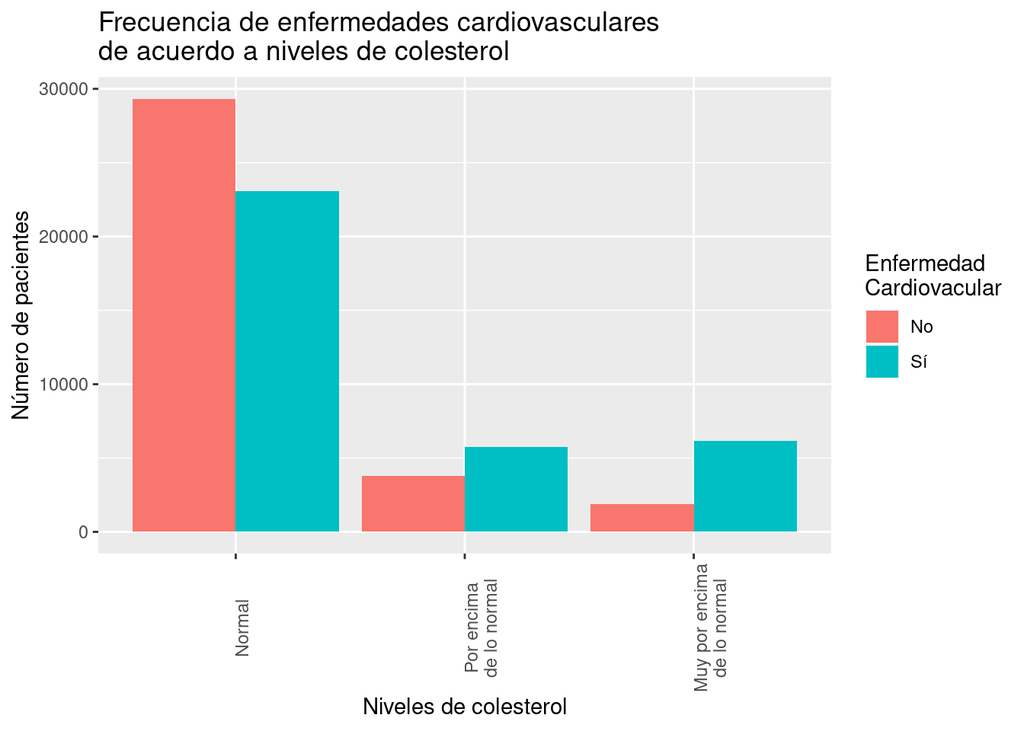

```r
# Frecuencia de pacientes por nivel de colesterol para ausencia y presencia de enfermedad cardiovascular
ggplot(double_counts, aes(x = Colesterol, y = Counts, fill = Cardiovascular)) +
  geom_bar(stat = "identity",  position=position_dodge()) +
  scale_fill_discrete(name = "Enfermedad \nCardiovacular", labels = c("No", "Sí")) +
  scale_x_discrete(labels = c("Normal", "Por encima\nde lo normal", "Muy por encima\nde lo normal")) +
  labs(title = "Frecuencia de enfermedades cardiovasculares\nde acuerdo a niveles de colesterol", x = "Niveles de colesterol", y = "Número de pacientes") +
  theme(axis.text.x = element_text(angle = 90))
```

**¿Encuentras alguna asociación entre ambas variables?**

Si, en los dos casos en los que el nivel de colesterol es superior al normal la presencia de enfermedades cardivasculares supera la ausencia de las mismas. Además en el caso de colesterol normal, la presencia de enfermedades cardiovasculares es menor que la ausencia.

Es decir, la presencia de enfermedades cardiovasculares se relaciona con el aumento de colesterol.

### Histograma

4. Realiza un histograma de la variable estatura y coloca una gráfica de densidad encima.

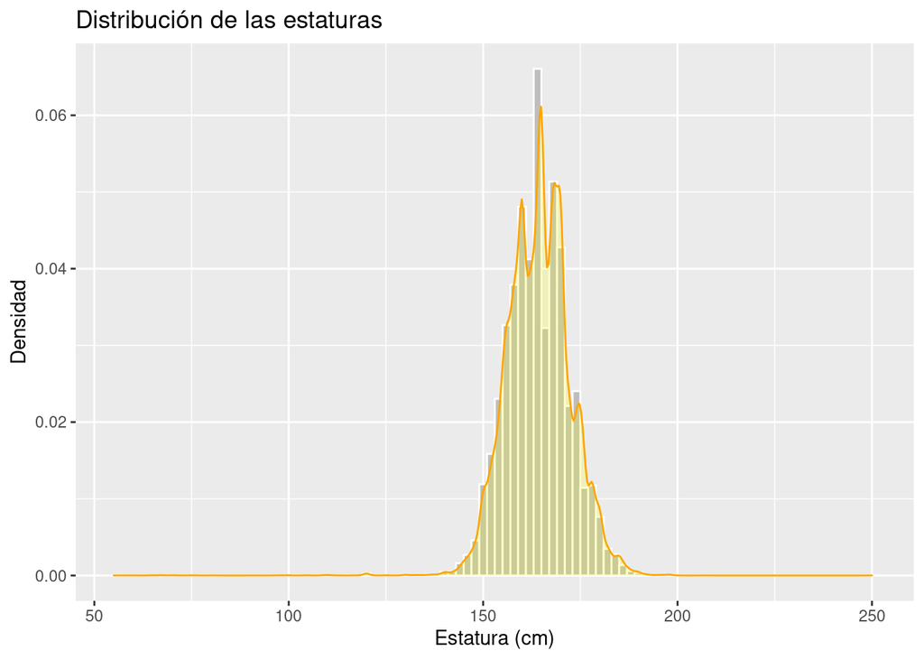

```r
# Histograma de densidad de estaturas
ggplot(dataset, aes(x = height)) +
  geom_histogram(aes(y=..density..), binwidth = 2, color = "white", fill = "gray") +
  geom_density(alpha = 0.2, fill = "yellow", color = "orange") +
  labs(title = "Distribución de las estaturas", x = "Estatura (cm)", y = "Densidad")
```

5. Realiza un histograma de la variable estatura agrupada por género.

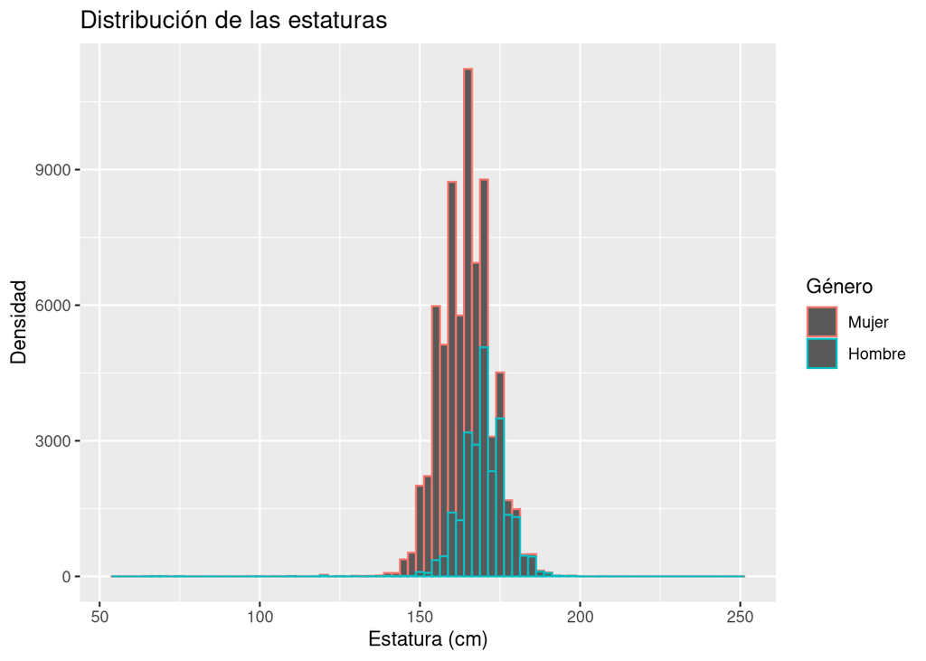

```r
# Histograma de densidad de estaturas y género
ggplot(dataset, aes(x = height, color = gender)) +
  geom_histogram(binwidth = 2.5) +
  labs(title = "Distribución de las estaturas", x = "Estatura (cm)", y = "Densidad") +
  scale_color_discrete(name = "Género", labels = c("Mujer", "Hombre"))
```

**¿Encuentras alguna asociación entre ambas variables?**

Las estaturas de los hombres se concentran en el lado derecho de la distribución, lo que indica que los hombres tienden a ser más altos que las mujeres.

### Gráficas de dispersión

6. Realiza una gráfica de dispersión con las variables tensión arterial sistólica y tensión arterial diastólica (limita el eje x a 250 y el eje y a 200). Coloca una línea de regresión encima.

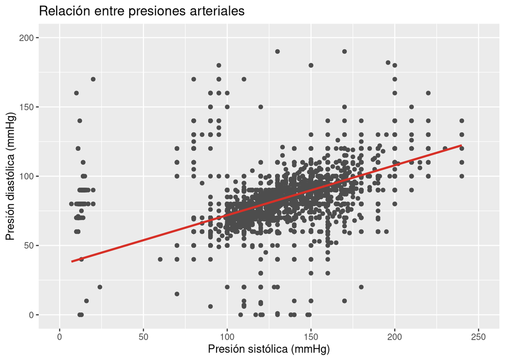

```r
# Gráfica de dispersión y relación entre presiones arteriales
 ggplot(dataset, aes(x = ap_hi, y = ap_lo)) +
  geom_point(color = "#4d4d4d") +
  xlim(0, 250) +
  ylim(0, 200) +
  geom_smooth(method = lm, color = "#d73027") +
  labs(title = "Relación entre presiones arteriales", x = "Presión sistólica (mmHg)", y = "Presión diastólica (mmHg)")
```

**¿Encuentras alguna asociación entre ambas variables?**

Si, según la regresión ambas variables (tensión arterial sistólica y diastólica) aumentan de acuerdo a la otra.

7. Realiza una gráfica de dispersión con las variables tensión arterial sistólica y tensión arterial diastólica (limita el eje x a 250 y el eje y a 200), agrupada por la presencia o ausencia de una enfermedad cardiovascular.

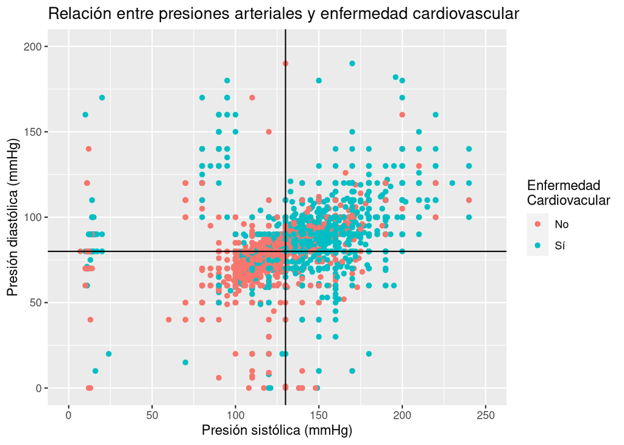

```r
# Gráfica de dispersión y relación entre presiones arteriales y enfermedades cardiovasculares
 ggplot(dataset, aes(x = ap_hi, y = ap_lo, color = cardio)) +
  geom_point() +
  xlim(0, 250) +
  ylim(0, 200) +
  geom_vline(xintercept = 130) +
  geom_hline(yintercept = 80) +
  labs(title = "Relación entre presiones arteriales y enfermedad cardiovascular", x = "Presión sistólica (mmHg)", y = "Presión diastólica (mmHg)") +
  scale_color_discrete(name = "Enfermedad \nCardiovacular", labels = c("No", "Sí"))
```

**¿Qué relación crees que existe entre estas tres variables?**

La hipertensión resulta ser una condición altamente relacionada con enfermedades cardiovasculares.

### *Boxplot*

8. Realiza un *boxplot* con la variable peso y la variable de enfermedad cardiovascular.

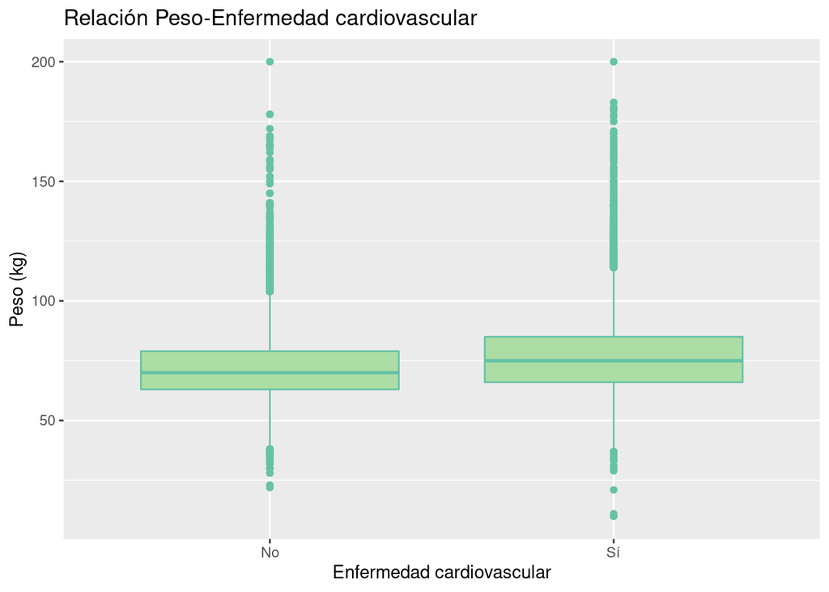

```r
# Relación peso y enfermedades cardiovasculares
ggplot(dataset, aes(x = cardio, y = weight)) +
  geom_boxplot(color = "#66c2a5", fill = "#abdda4") +
  scale_x_discrete(labels = c("No", "Sí")) +
  labs(title = "Relación Peso-Enfermedad cardiovascular", x = "Enfermedad cardiovascular", y = "Peso (kg)")
```

**¿Qué puedes deducir sobre el peso de los pacientes con enfermedades cardiovasculares?**

9. Realiza un boxplot con la variable peso y la variable de enfermedad cardiovascular, agrupadas por la variable “fumar”.

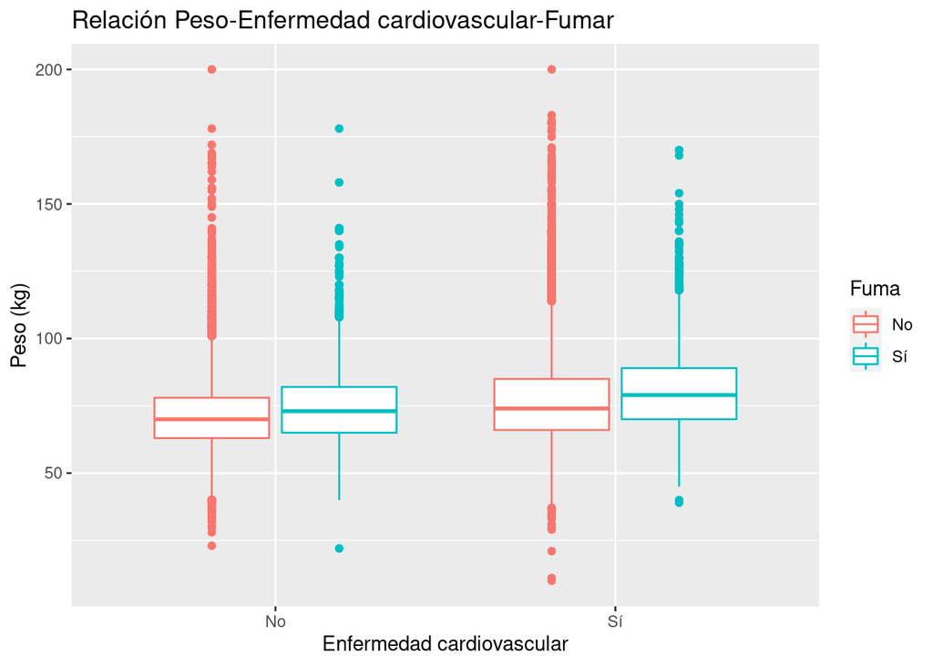

```r
# Relación peso, enfermedades cardiovasculares y fumar
ggplot(dataset, aes(x = cardio, y = weight, color = smoke)) +
  geom_boxplot() +
  scale_x_discrete(labels = c("No", "Sí")) +
  scale_color_discrete(name = "Fuma", labels = c("No", "Sí")) +
  labs(title = "Relación Peso-Enfermedad cardiovascular-Fumar", x = "Enfermedad cardiovascular", y = "Peso (kg)")
```

**¿Qué relación existe entre las tres variables?**

Entre la presencia y ausencia de enfermedades cardiovasculares, los pacientes con enfermedades cardiovasculares tienen mayor peso. Además en ambos casos las personas que fuman pesan más. Así el subgrupo con mayo peso son pacientes que fuman y enfermedades cardiovasculares.

### *Heatmap*

10. Realiza un *heatmap* de la edad en años, la presión arterial sistólica, la presión arterial diastólica, la estatura y el peso, contra los grupos obtenidos de las combinaciones entre las variables colesterol y enfermedad cardiovascular (debes obtener un heatmap de 6x5).

```r
# Extraer datos de interés
hm_data <- aggregate(dataset[,c(3,5:8)],
          by = list(dataset$cholesterol, dataset$cardio), # Agrupar por dos categorías (CVD - colesterol)
          median, na.rm = T) # Obtener mediana

# Combinar las dos categorías de comparación en una sola
Group.1 <-sort(unique(paste(dataset$cardio, dataset$cholesterol, sep = "-")))
# Datos originales
hm_data
```

```
##   Group.1 Group.2 age_year height weight ap_hi ap_lo
## 1       1       0 51.84932    165     70   120    80
## 2       2       0 53.49863    163     72   120    80
## 3       3       0 56.08630    164     73   125    80
## 4       1       1 55.61644    165     74   130    80
## 5       2       1 55.49041    164     77   140    90
## 6       3       1 57.63014    163     78   130    82
```

```r
# Sustituir las dos categorías por una combinada (debe coincidir con el orden de los datos originales)
hm_data <- cbind(Group.1, hm_data[,3:7])
# Datos modificados
hm_data
```

```
##   Group.1 age_year height weight ap_hi ap_lo
## 1     0-1 51.84932    165     70   120    80
## 2     0-2 53.49863    163     72   120    80
## 3     0-3 56.08630    164     73   125    80
## 4     1-1 55.61644    165     74   130    80
## 5     1-2 55.49041    164     77   140    90
## 6     1-3 57.63014    163     78   130    82
```

```r
# Transformar de datos a formato long
hm_data <- reshape(hm_data,
                   direction = "long",
                   varying = list(names(hm_data)[2:6]),
                   v.names = "Value",
                   idvar = "Group.1",
                   timevar = "Variable",
                   times = colnames(hm_data)[2:6])

# Eliminar nombres de los renglones
row.names(hm_data) <- NULL
```

Los datos son de categorías muy distintas, lo que lo vuelve poco comparables (numéricas y categóricas). Por esta razón es necesario normalizarlos.

```r
# Normalizar de datos
hm_data$Value <- log(hm_data$Value)
# Datos normalizados
hm_data[1:15,]
```

```
##    Group.1 Variable    Value
## 1      0-1 age_year 3.948342
## 2      0-2 age_year 3.979656
## 3      0-3 age_year 4.026892
## 4      1-1 age_year 4.018479
## 5      1-2 age_year 4.016210
## 6      1-3 age_year 4.054046
## 7      0-1   height 5.105945
## 8      0-2   height 5.093750
## 9      0-3   height 5.099866
## 10     1-1   height 5.105945
## 11     1-2   height 5.099866
## 12     1-3   height 5.093750
## 13     0-1   weight 4.248495
## 14     0-2   weight 4.276666
## 15     0-3   weight 4.290459
```

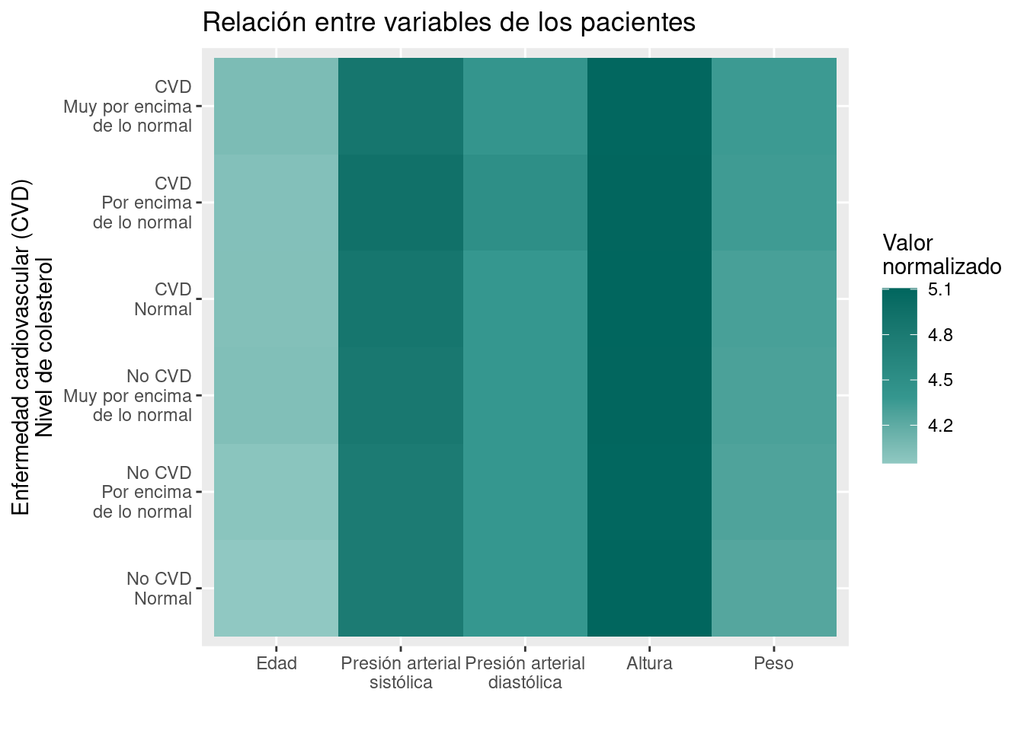

```r
# Heatmap para ver la relación de las variables
ggplot(hm_data, aes(x = Variable, y = Group.1, fill = Value)) +
  geom_tile() +
  scale_fill_gradient2(low = "#c7eae5", high = "#01665e", mid = "#35978f", midpoint = median(hm_data$Value)) +
  labs(title = "Relación entre variables de los pacientes", x = "", y = "Enfermedad cardiovascular (CVD)\nNivel de colesterol", fill = "Valor\nnormalizado") +
  scale_y_discrete(labels = c("No CVD\nNormal", "No CVD\nPor encima\nde lo normal", "No CVD\nMuy por encima\nde lo normal","CVD\nNormal", "CVD\nPor encima\nde lo normal", "CVD\nMuy por encima\nde lo normal")) +
  scale_x_discrete(labels = c("Edad", "Presión arterial\nsistólica", "Presión arterial\ndiastólica", "Altura", "Peso"))
```